# Praca domowa 2

Aleksandra Dmitruk

## Dane

Dane wykorzystane w Pracy domowej 2 dotyczą wyników egzaminów z 3 umiejętności: czytania, pisania i operacji matematycznych. Dodatkowo dostępne są podstawowe informacje o studentach i ich rodzicach. Opis wszystkich kolumn znajduje się również w pliku `README.md`.

| Zmienna | Opis |
| --- | --- |
| **gender** | płeć |
| **race.ethnicity** | pochodzenie etniczne |
| **parental.level.of.education** | wykształcenie rodziców |
| **lunch** | jaki obiad jedli uczniowie w dniu egzaminu |
| **test.preparation.course** | czy uczeń odbył kurs przygotowujący |
| **math.score** | wynik egzaminu z matematyki |
| **reading.score** | wynik egzaminu z czytania |
| **writing.score** | wynik egzaminu z pisania |

## Zadanie 1

Jak wyglądają rozkłady wyników uczniów z trzech przedmiotów (matematyka, czytanie, pisanie)?

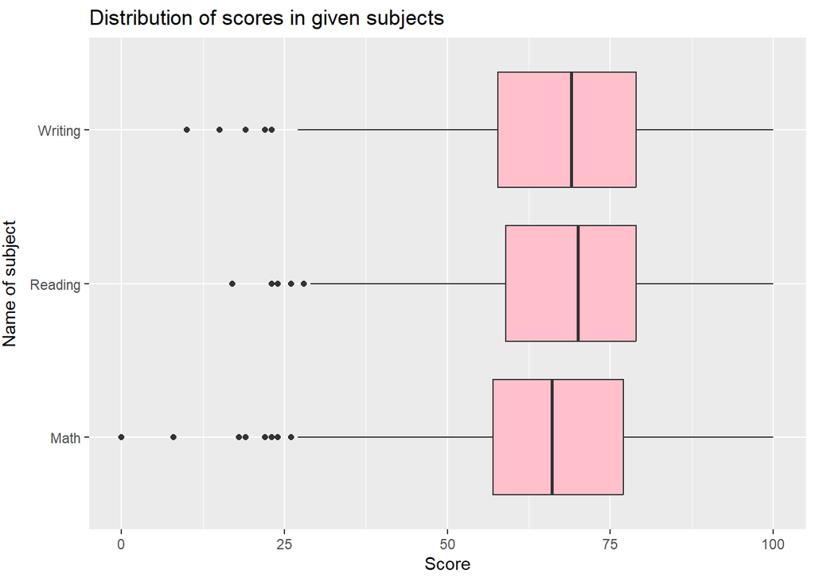

```r
df_pivoted <- df %>%
  select(c(gender, math.score, reading.score, writing.score)) %>%
  rename(Math = math.score,
         Reading = reading.score,
         Writing = writing.score) %>%
  pivot_longer(cols = c(Math, Reading,Writing))

df_pivoted %>%
  ggplot(aes(x = value, y = name)) +
  geom_boxplot(fill = "pink") +
  labs(title = "Distribution of scores in given subjects",
       x = "Score",
       y = "Name of subject") +
  theme(axis.title.y = element_text(vjust=3))
```

**Komentarz:** Z wykresu wynika, że najniższą medianę mają wyniki z egzaminu z matematyki i także dla tego przedmiotu zostały zaobserwowane najniższe wyniki. Wyniki z egzaminu z pisania i czytania są zbliżone i są wyższe niż te z egzaminu z matematyki, a także jest z nich mniej wyników najgorszych, tzn. żaden uczeń nie otrzymał wyniku zerowego.

## Zadanie 2

Czy istnieje zauważalna różnica w wynikach między uczniami i uczennicami?

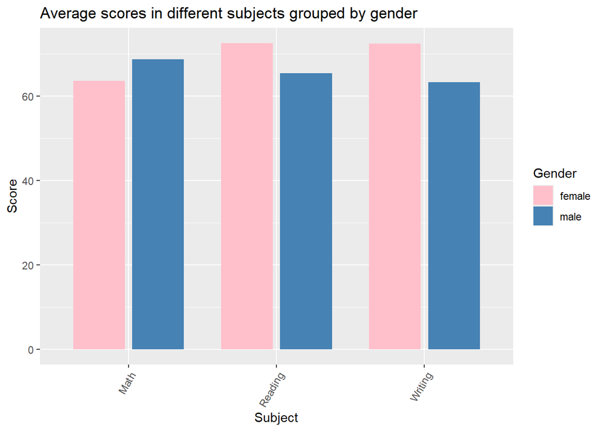

```r
df %>%
  select(c(gender, math.score, reading.score, writing.score)) %>%
  group_by(gender) %>%
  summarise(Math = mean(math.score),
            Reading = mean(reading.score),
            Writing = mean(writing.score)
            ) %>%
  pivot_longer(cols = c(Math, Reading, Writing)) %>%
  ggplot(aes(x = name, y = value, fill = gender)) +
  geom_col(position = position_dodge(width = 0.8), width = 0.7) +
  scale_fill_manual(values = c("female" = "pink", "male" = "steelblue")) +
  labs(
    x = "Subject",
    y = "Score",
    fill = "Gender",
    title = "Average scores in different subjects grouped by gender"
  ) +
  theme(
    axis.text.x = element_text(angle = 60, hjust = 1)
  )
```

**Komentarz:** Z egzaminów z czytania i pisania uczennice osiągają średnio wyższe wyniki niż chłopcy, niższe natomiast z matematyki, jednak dla wszystkich przedmiotów i dla obu płci średnie wyniki są wyższe niż 60%.

## Zadanie 3

Czy uczniowie, którzy ukończyli kurs przygotowawczy, osiągają lepsze wyniki niż pozostali?

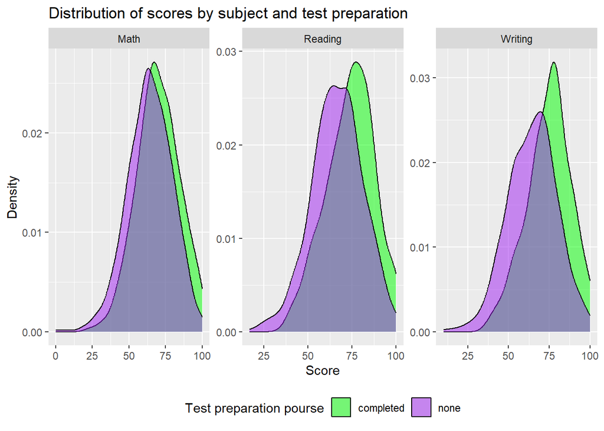

```r
df %>%
  select(c(test.preparation.course, math.score, reading.score, writing.score)) %>%
  rename(Math = math.score,
         Reading = reading.score,
         Writing = writing.score) %>%
  pivot_longer(cols = c(Math, Reading, Writing),
               names_to = "subject", values_to = "score") %>%
  ggplot(aes(x = score, fill = test.preparation.course))+
  geom_density(alpha = 0.5)+
  facet_wrap(~subject, scale = "free")+
  labs(title = "Distribution of scores by subject and test preparation",
       x = "Score", y = "Density", fill = "Test preparation pourse")+
  scale_fill_manual(values = c("green", "purple"))+
  theme(legend.position = "bottom")
```

**Komentarz:** Uczniowie, którzy ukończyli kurs przygotowawczy osiągneli lepsze wyniki z każdego przedmiotu. Wyniki uczniów uczęszczających na kurs są skupione wokół wyższych wartości, a gęstość wyników najgorszych jest zdecydowanie mniejsza dla uczniów po kursie. Uczęszczanie na kurs z pisania jest najbardziej korzystne, bo to po nim uczniowie mają zdecydowanie lepsze wyniki, niż ci co na kurs nie uczęszczali. W przypadku matematyki ta różnica jest najmniejsza.

## Zadanie 4

Jaki jest związek między poziomem wykształcenia rodziców a średnimi wynikami uczniów?

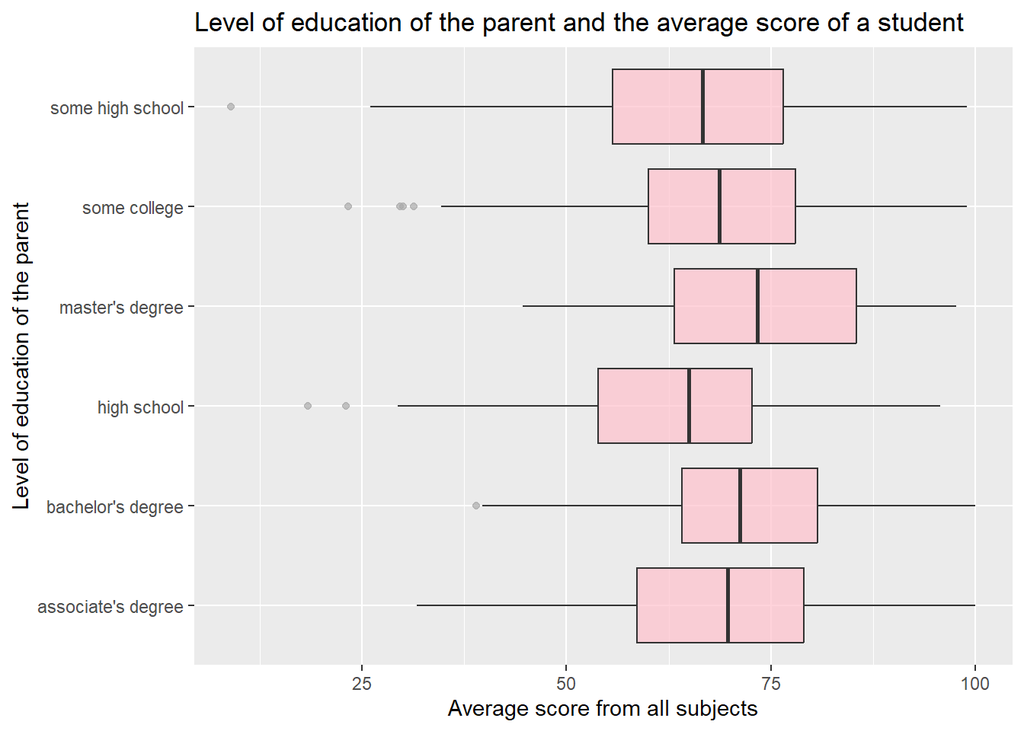

```r
df %>%
  select(parental.level.of.education) %>%
  mutate(average_score = rowMeans(df[ ,c("math.score", "reading.score", "writing.score")])) %>%
  ggplot(aes(x = average_score, y = parental.level.of.education))+
  geom_boxplot(outlier.colour = "darkgray", fill = "pink", alpha = 0.7)+
  labs(title = "Level of education of the parent and the average score of a student",
       x = "Average score from all subjects",
       y = "Level of education of the parent")
```

## Zadanie 5

Czy płeć i wykształcenie rodzica wpływa na wynik z matematyki?

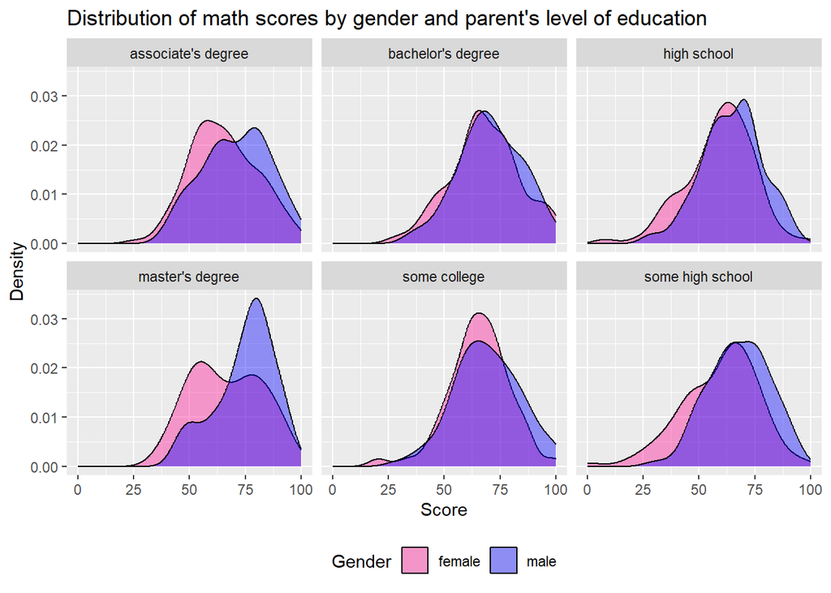

```r
df %>%
  select(c(gender, parental.level.of.education, math.score)) %>%
  ggplot(aes(x = math.score, fill = gender))+
  geom_density(alpha = 0.4)+
  facet_wrap(~parental.level.of.education)+
  labs(title = "Distribution of math scores by gender and parent's level of education",
       x = "Score", y = "Density", fill = "Gender")+
  theme(legend.position = "bottom")+
  scale_fill_manual(values = c("deeppink", "blue"))
```

## Zadanie 6

Czy istnieje zależność między wynikami z matematyki a wynikami z czytania lub pisania?

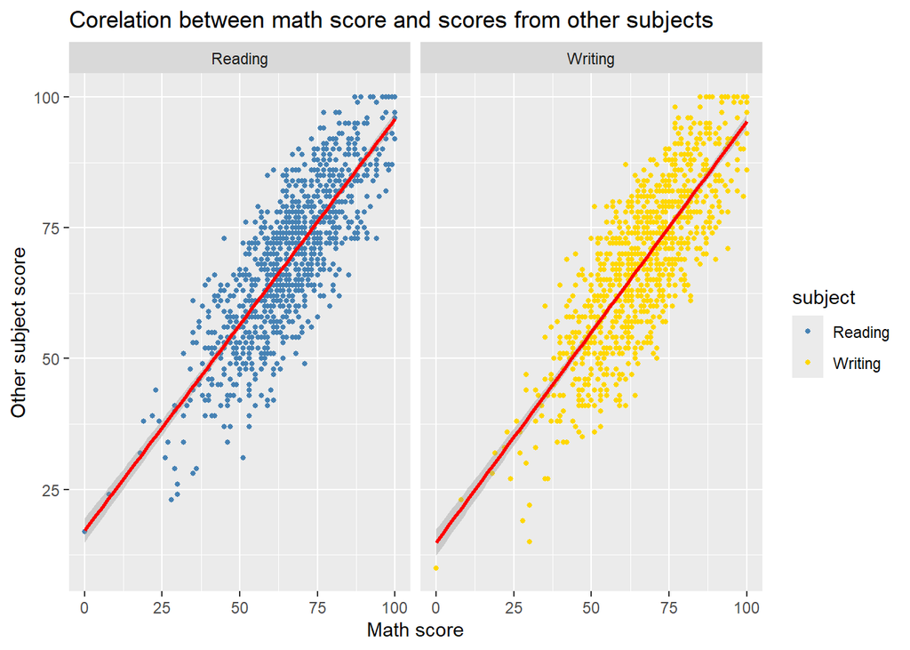

```r
df %>%
  select(c(math.score, reading.score, writing.score)) %>%
    rename(Math = math.score,
         Reading = reading.score,
         Writing = writing.score) %>%
  pivot_longer(cols = c(Reading, Writing),
               names_to = "subject",
               values_to = "score") %>%
  ggplot(aes(x = Math, y = score, colour = subject)) +
  facet_wrap(~subject) +
  geom_point(size = 1) +
  scale_color_manual(values = c("steelblue", "gold")) +
  geom_smooth(method = "lm", color = "red") +
  labs(title = "Corelation between math score and scores from other subjects",
       x = "Math score",
       y = "Other subject score")
```

**Komentarz:** Między wynikiem z matematyki, a wynikami z czytania lub pisania jest jasno widoczna zależność liniowa. Uczniowie o wysokim wyniku z matematyki mają też wysokie wyniki z innych przedmiotów i odwrotnie.